# R Notebook

```r
load("/Users/aizamalik/Desktop/BST260/Project/BST260_project_data.RDa")
```

```r
library(dplyr)
library(tidyverse)
library(maps)
library(stringr)
```

Purpose: to visualize which cuisines, grouped by country, are the most interacted with (have the most ratings) and which ones are most common (number of recipes of a specific cuisine).

```r
head(data_final)
```

|  | recipe | cook_time | prep_time | course | cuisine | rating | n_ratings | servings | ingredients | n_ingredients | n_steps | calories | carbs | protein | fat | sat_fat | poly_fat | mono_fat | sodium | potassium | fiber | sugar | vitamin_c | vitamin_a | calcium | iron |
| --- | --- | --- | --- | --- | --- | --- | --- | --- | --- | --- | --- | --- | --- | --- | --- | --- | --- | --- | --- | --- | --- | --- | --- | --- | --- | --- |
| 1 | Baked Mac and Cheese | 60 | 10 | Side | Western | 5.00 | 355 | 6 | macaroni (elbow pasta); unsalted butter ; panko breadcrumbs; unsalted butter; salt; unsalted butter; flour; milk; freshly shredded cheese, gruyere best; freshly shredded mozzarella cheese; salt; garli… | 14 | 13 | 551 | 48 | 23 | 29 | 17 | NA | NA | 847 | 326 | 1 | 8 | 0 | 915 | 449 | 1 |
| 2 | Cheesy Potato Gratin Stacks (Muffin Tin) | 45 | 15 | Finger Food, Side | French | 4.99 | 75 | 12 | Oil spray; starchy potatoes; butter; garlic cloves; heavy / thickened cream; fresh thyme leaves; salt; Black pepper; gruyere cheese ; gruyere cheese | 10 | 13 | 169 | 16 | 5 | 10 | 6 | 1 | 3 | 200 | 371 | 1 | 1 | 5 | 342 | 110 | 1 |
| 3 | Pad See Ew – Thai Stir Fried Noodles | 10 | 8 | Noodles, Stir Fry | Thai | 4.96 | 227 | 2 | dried wide rice stick noodles; dark soy sauce; oyster sauce; soy sauce; white vinegar; sugar; water; peanut or vegetable oil; garlic cloves, very finely chopped; chicken thighs; large egg; stems Chine… | 12 | 11 | 510 | 73 | 25 | 13 | 2 | NA | NA | 406 | 169 | 1 | 2 | 75 | 9600 | 40 | 1 |
| 4 | Bangers & Mash (Sausage with Onion Gravy) | 20 | 5 | Dinner | Australian, British | 5.00 | 61 | 4 | oil; sausages of choice; large onion; garlic cloves; flour; beef stock/broth; salt; black pepper; Mashed potato; Peas | 10 | 9 | 666 | 7 | 36 | 53 | 16 | NA | NA | 1703 | 632 | 0 | 1 | 5 | 50 | 40 | 2 |
| 5 | Blueberry Bread Loaf | 60 | 15 | Sweets | Baking | 4.98 | 36 | 8 | flour; white sugar; baking powder; Pinch of salt; plain yoghurt; large eggs ; lemon zest; vanilla extract; canola oil; flour; frozen or fresh blueberries; soft icing sugar / powdered sugar; lemon juic… | 14 | 9 | 377 | 60 | 5 | 14 | 2 | 4 | 8 | 33 | 185 | 1 | 41 | 4 | 110 | 79 | 1 |
| 6 | Really Quick Broccoli Pasta | 10 | 5 | Mains, Side | Western | 4.97 | 81 | 4 | dried short pasta; broccoli heads; shredded cheese (or more!); lemon zest; lemon juice; extra virgin olive oil; parmesan; garlic cloves; mixed dried herbs; red pepper flakes; sugar; salt; pepper; More… | 14 | 8 | 634 | 71 | 23 | 29 | 9 | NA | NA | 768 | 609 | 6 | 5 | 116 | 1270 | 347 | 2 |

```r
world_map = map_data("world")
```

First, I created a data frame ‘commonentries’ that counts the instances of an entry and arranges them in descending order by frequency. Then I created a dataframe ‘commonratings’ that counts the number of ratings each cuisine entry type has and arranges them in descending order. I combined these two data frames into a new dataframe ‘commonvalues2’.

```r
#commonstrings <- data_final %>% add_count(frequency = cuisine) %>% arrange(., desc(n), by_group = frequency)

#By number of entries in data frame:
commonentries <- data_final %>% group_by(cuisine) %>% summarise(count=n()) %>% arrange(desc(count))

#By number of ratings
commonratings <- data_final %>% group_by(cuisine) %>% filter(!is.na(n_ratings)) %>% summarise(count=sum(n_ratings)) %>% arrange(desc(count))

#Ratings normalized for number of recipes
commonvalues <- left_join(commonentries, commonratings, by = "cuisine")
commonvalues2 <- commonvalues %>% group_by(cuisine) %>% mutate(normalized = sum(count.y/count.x)) %>% arrange(desc(normalized))
```

To simplify the mapping analysis I chose to focus on entries that gave us country-specific information. I excluded any regional entries and created a new data frame with the top 10 entries from ‘commonvalues2’. I created a new column to have cuisine types match up with regions in ‘world map’ and then combined these data frames.

```r
common <- commonvalues2 %>% filter(cuisine %in% c("Mexican", "Italian", "Chinese", "Thai", "French", "Indian", "Greek", "Vietnamese", "American", "Asian, Japanese")) %>% arrange(desc(count.x))
Countries = c("Mexico", "Italy", "China", "Thailand", "France", "India", "Greece", "Vietnam", "USA", "Japan")
common$region <- Countries
```

```r
world_map_data <- left_join(world_map, common, by = "region")
```

World maps mapping the cuisines with the most number of recipes and which cuisine was interacted with most frequently (measured by number of ratings for each cuisine)

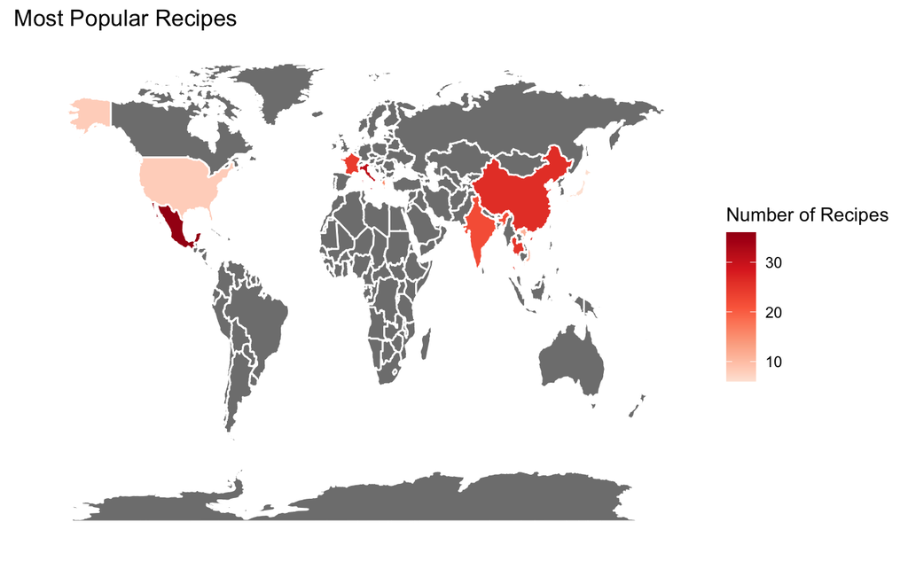

```r
library(RColorBrewer)
world_map_data %>% ggplot(aes(x = long, y = lat, group = group, fill = count.x)) +
   geom_polygon(color = "white") + scale_fill_gradientn(colors = brewer.pal(5, "Reds"),name="Number of Recipes") +
   theme(panel.grid.major = element_blank(),
         panel.background = element_blank(),
         axis.title = element_blank(),
         axis.text = element_blank(),
         axis.ticks = element_blank()) + ggtitle("Most Popular Recipes")
```

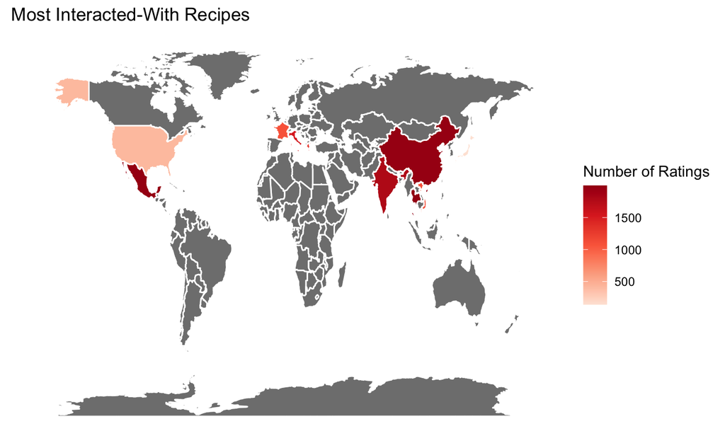

```r
library(RColorBrewer)
world_map_data %>% ggplot(aes(x = long, y = lat, group = group, fill = count.y)) +
   geom_polygon(color = "white") + scale_fill_gradientn(colors = brewer.pal(5, "Reds"), name="Number of Ratings") +
   theme(panel.grid.major = element_blank(),
         panel.background = element_blank(),
         axis.title = element_blank(),
         axis.text = element_blank(),
         axis.ticks = element_blank()) + ggtitle("Most Interacted-With Recipes")
```